# Static Style and Design

## Farm Payments

Many farms receive payments from the government through subsidies. Most subsidies fund commodity crops, such as corn, wheat, and cotton. Subsidies are concentrated in states that produce these commodities, mostly in the Midwest and Plains states. Because of the relationship between crops and subsidies, the state that receives the most government payments is not the state with the most farms.

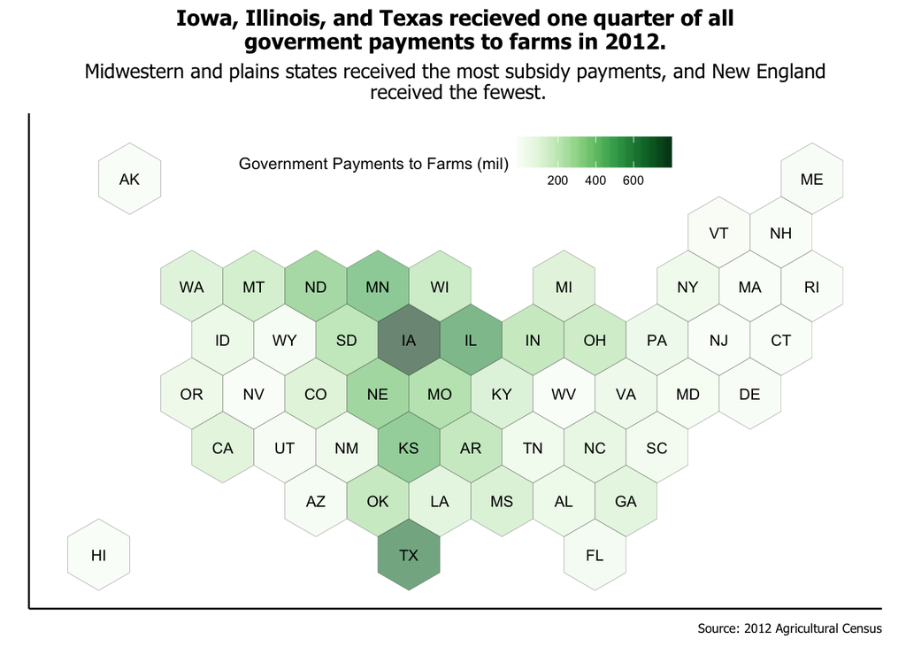

```r
access <- read_xlsx("foodAtlas.xlsx", sheet = 5)
assistance <- read_xlsx("foodAtlas.xlsx", sheet = 6)
security <- read_xlsx("foodAtlas.xlsx", sheet = 8)
health <- read_xlsx("foodAtlas.xlsx", sheet = 7)
farmsTime <- read_xlsx("farmnumbers.xlsx")
agCensus <- read_csv("agcensus.csv")
access <- access %>%
  mutate(FIPS = as.integer(FIPS))
assistance <- assistance %>%
  mutate(FIPS = as.integer(FIPS))
security <- security %>%
  mutate(FIPS = as.integer(FIPS))
health <- mutate(health, FIPS = as.integer(FIPS))

accAss <- right_join(access, assistance, by = "FIPS")
accAssSec <- right_join(accAss, security, by = "FIPS")
ctyFarms <- inner_join(accAssSec, agCensus, by = "FIPS")
ctyFarms <- inner_join(ctyFarms, health, by = "FIPS") %>%
              filter(COUNICP != 0)
farm_payments <- ctyFarms %>%
  group_by(State.x) %>%
  summarise(payments = sum(DATA1_33, na.rm = TRUE))
#code for hex map from: https://www.r-graph-gallery.com/328-hexbin-map-of-the-usa/
# Hexbin available in the geojson format here: https://team.carto.com/u/andrew/tables/andrew.us_states_hexgrid/public/map. Download it and then:
spdf <- geojson_read("us_states_hexgrid.geojson.json",  what = "sp")

farm_payments <- read_xlsx("farmpayments.xlsx")%>%
  mutate(Payments = Payments/1000)


spdf@data = spdf@data %>% mutate(google_name = gsub(" \\(United States\\)", "", google_name))
spdf_fortified <- tidy(spdf, region = "google_name")

centers <- cbind.data.frame(data.frame(gCentroid(spdf, byid=TRUE), id=spdf@data$iso3166_2))
centers <- centers %>% filter(id != "DC")

spdf_fortified = spdf_fortified %>%
  left_join(. , farm_payments, by=c("id"="State"))

spdf_fortified %>%
  filter(id != "District of Columbia") %>%
  ggplot() +
    geom_polygon(aes(fill = Payments, x = long, y = lat, group = group),
                 size=0.05, alpha=0.6, color="black") +
    main_theme +
    coord_map() +
    geom_text(data=centers, aes(x=x, y=y, label=id), color="black", size=3) +
    scale_fill_gradientn(colours=brewer.pal(10, "Greens"),
                         name="Government Payments to Farms (mil)",
                         labels = comma) +
  theme(legend.position = c(0.5, 0.9),
    plot.background = element_blank(),
    axis.title.x  = element_blank(),
    axis.title.y = element_blank(),
    axis.text.x = element_blank(),
    axis.text.y = element_blank(),
    axis.ticks = element_blank()) +
  labs(title = "Iowa, Illinois, and Texas recieved one quarter of all\ngoverment payments to farms in 2012.",
       caption = "Source: 2012 Agricultural Census",
       subtitle = "Midwestern and plains states received the most subsidy payments, and New England\n received the fewest.")
```

## Farm Size

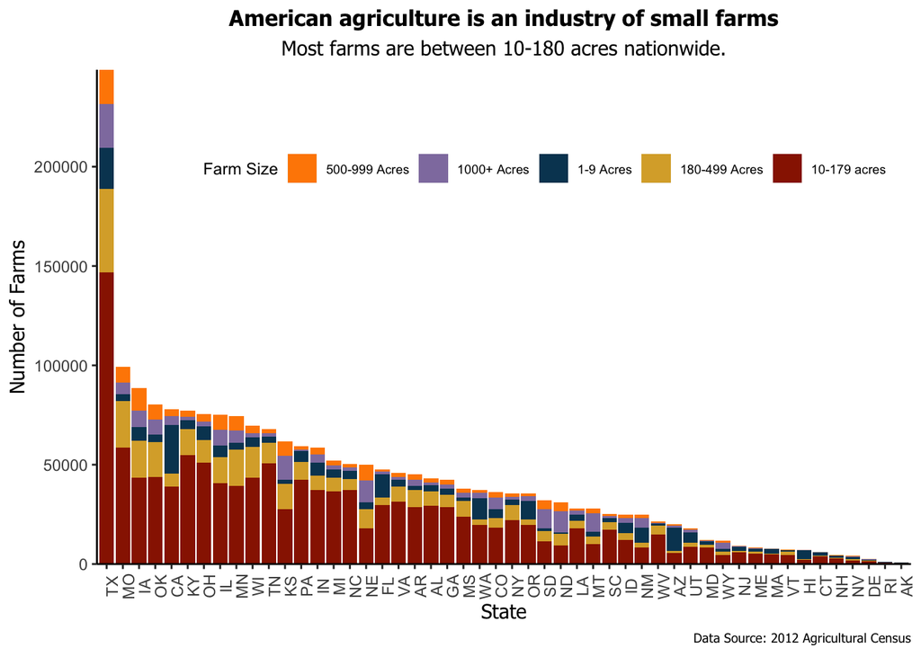

```r
frm_size <- read_xlsx("farmsize.xlsx")

frm_size %>%
  mutate(State.x = as.factor(State.x),
         State.x = fct_reorder(State.x, -all_farms),
         farm_size = as.factor(farm_size),
         farm_size = fct_collapse(farm_size,
                                  "10-179 acres" = c("10-49 Acres", "50-179 Acres")),
         farm_size = fct_reorder(farm_size, total_farms))%>%
  ggplot(aes(x = State.x, y = total_farms)) +
    geom_col(aes(fill = farm_size)) +
    labs(x = "State",
         y = "Number of Farms",
         title = "American agriculture is an industry of small farms",
         subtitle = "Most farms are between 10-180 acres nationwide.",
         caption = "Data Source: 2012 Agricultural Census",
         fill = "Farm Size") +
    main_theme +
    theme(axis.text.x = element_text(angle = 90),
          strip.text = element_text(face = "bold",
                                  size = rel(0.2)),
          legend.position = c(0.55, 0.8))+
  scale_y_continuous(expand = c(0, 0)) +
  scale_fill_manual(values = categorical_cols, aesthetics = "fill")
```

## Food Security and Farms

There is a positive relationship between number of farms in a state and number of residents with low food access. Low access to food is defined as living more than one mile away from a groccery store in urban areas, and more than 10 miles away from a groccery store in rural areas. Food insecurity is defined as being unable to provide adequate food for one or more household members at some time during the year. While food access is related to number of farms, food insecurity is not related to access to food. There may be food produced in a state, but the ability of residents to buy that food is another matter entirely.

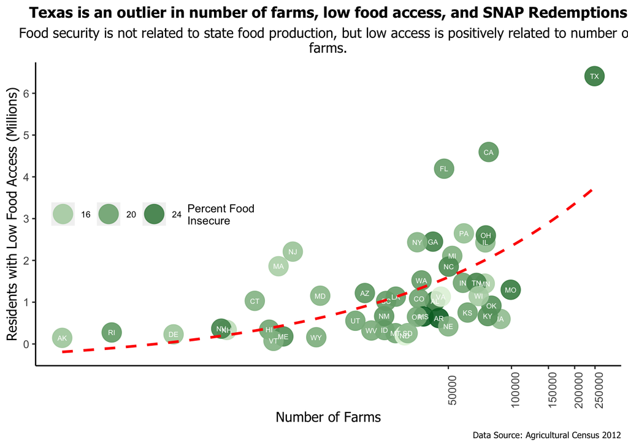

```r
byState <- ctyFarms %>%
  group_by(State.x) %>%
  summarise(low_acc_pop = sum(LACCESS_POP10)/1000000,
            farms = sum(DATA1_1),
            snap_redemp = sum(REDEMP_SNAPS12,
                              na.rm = TRUE)/1000000,
            payments = sum(DATA1_33, na.rm = TRUE),
            cropland = sum(DATA1_15, na.rm = TRUE),
            farmland = sum(DATA1_2, na.rm = TRUE),
            avg_land = mean(DATA1_3, na.rm = TRUE),
            obeseAd = mean(PCT_OBESE_ADULTS13),
            insec = mean(VLFOODSEC_10_12 + FOODINSEC_10_12)) %>%
  filter(State.x != "0")
accAss <- right_join(access, assistance, by = "FIPS")
accAssSec <- right_join(accAss, security, by = "FIPS")
ctyFarms <- inner_join(accAssSec, agCensus, by = "FIPS")
ctyFarms <- inner_join(ctyFarms, health, by = "FIPS") %>%
              filter('COUNICP' != 0)

byState %>%
  ggplot(aes(x = farms, y = low_acc_pop)) +
    geom_point(aes(color = insec),
               alpha = 0.9,
               size = 7) +
    geom_text(aes(label = State.x),size = 2, color = "white") +
    scale_size_continuous(range = c(3, 8), labels = comma) +
    scale_y_continuous(breaks = pretty(byState$low_acc_pop)) +
    scale_x_log10(breaks = pretty(byState$farms))+
    scale_color_continuous(low = "#e5f5e0",
                           high = "#006d2c") +
  labs(x = "Number of Farms",
       y = "Residents with Low Food Access (Millions)",
       color = "Percent Food\nInsecure",
       caption = "Data Source: Agricultural Census 2012",
         title = "Texas is an outlier in number of farms, low food access, and SNAP Redemptions",
         subtitle = "Food security is not related to state food production, but low access is positively related to number of \nfarms.") +
  main_theme +
  theme(legend.position = c(0.2, 0.5),
        legend.background = element_rect(fill = "transparent"),
        legend.title = element_text(size = 9),
        axis.text.x = element_text(angle = 90)) +
  guides(colour = guide_legend(title.position = "right"),
         size = guide_legend(title.position = "right")) +
  stat_smooth(method="lm", se=FALSE,
                formula=(y ~ exp(x)),colour="red", linetype = "dashed")
```